# A Tutorial to Learn Data Science with Python from Scratch

### Author: Daniel Fernando Mera

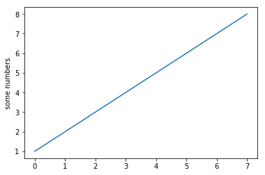

```python
import matplotlib.pyplot as plt
plt.plot([1,2,3,4,5,6,7,8])
plt.ylabel('some numbers')
plt.show()
```

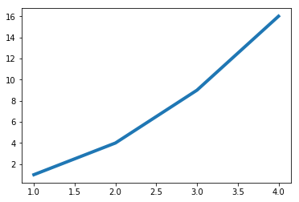

```python
import matplotlib.pyplot as plt
plt.plot([1, 2, 3, 4], [1, 4, 9, 16],linewidth=4.0)
plt.show()
```

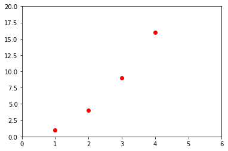

```python
import matplotlib.pyplot as plt
plt.plot([1,2,3,4], [1,4,9,16], 'ro')
plt.axis([0, 6, 0, 20])
plt.show()
```

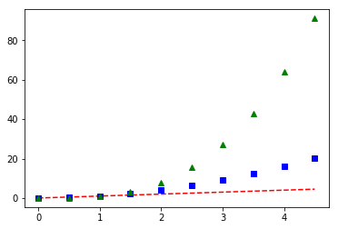

```python
import numpy as np
import matplotlib.pyplot as plt

# evenly sampled time at 200ms intervals
t = np.arange(0., 5., 0.5)

# red dashes, blue squares and green triangles
plt.plot(t, t, 'r--', t, t**2, 'bs', t, t**3, 'g^')
plt.show()
```

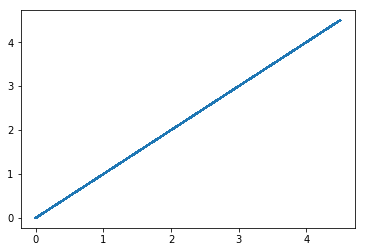

```python
x = np.arange(0., 5., 0.5)
y = np.arange(0., 5., 0.5)
line, = plt.plot(x, y, '-')
line.set_antialiased(False) # turn off antialising
plt.show()
```

## Working with multiple figures and axes

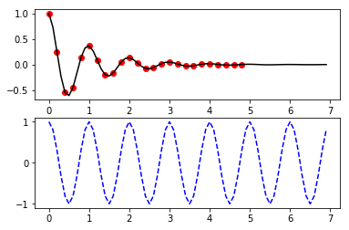

```python
import numpy as np
import matplotlib.pyplot as plt

def f(t):
    return np.exp(-t) * np.cos(2*np.pi*t)

t1 = np.arange(0.0, 5.0, 0.2)
t2 = np.arange(0.0, 7.0, 0.1)

plt.figure(1)
plt.subplot(211)
plt.plot(t1, f(t1), 'ro', t2, f(t2), 'k')

plt.subplot(212)
plt.plot(t2, np.cos(2*np.pi*t2), 'b--')
plt.show()
```

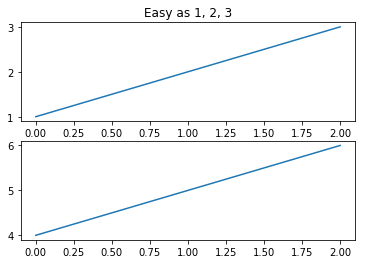

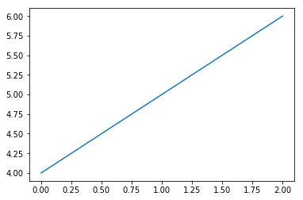

```python
import matplotlib.pyplot as plt
plt.figure(1)                # the first figure
plt.subplot(211)             # the first subplot in the first figure
plt.plot([1, 2, 3])
plt.subplot(212)             # the second subplot in the first figure
plt.plot([4, 5, 6])


plt.figure(2)                # a second figure
plt.plot([4, 5, 6])          # creates a subplot(111) by default

plt.figure(1)                # figure 1 current; subplot(212) still current
plt.subplot(211)             # make subplot(211) in figure1 current
plt.title('Easy as 1, 2, 3') # subplot 211 title

plt.show()
```

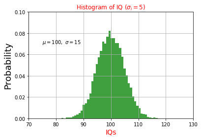

```python
import numpy as np
import matplotlib.pyplot as plt

# Fixing random state for reproducibility
np.random.seed(19680801)

mu, sigma = 100, 5
x = mu + sigma * np.random.randn(10000)

# the histogram of the data
n, bins, patches = plt.hist(x, 50, normed=1, facecolor='g', alpha=0.75)


t = plt.xlabel('my data', fontsize=14, color='red')
plt.xlabel('IQs')
plt.ylabel('Probability',fontsize =18)
plt.title('Histogram of IQ ' r'($\sigma_i=5$)', color ='red')
plt.text(75, .07, r'$\mu=100,\ \sigma=15$')
plt.axis([70, 130, 0, 0.10])
plt.grid(True)
plt.show()
```

### Annotating text

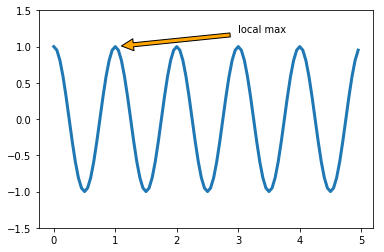

```python
import numpy as np
import matplotlib.pyplot as plt

ax = plt.subplot(1,1,1)

t = np.arange(0.0, 5.0, 0.05)
s = np.cos(2*np.pi*t)
line, = plt.plot(t, s, lw=3)

plt.annotate('local max', xy=(1, 1), xytext=(3, 1.2),
            arrowprops=dict(facecolor='orange', shrink=0.05),
            )

plt.ylim(-1.5,1.5)
plt.show()
```

## Logarithmic and other nonlinear axes

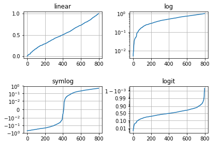

```python
import numpy as np
import matplotlib.pyplot as plt

from matplotlib.ticker import NullFormatter  # useful for `logit` scale

# Fixing random state for reproducibility
np.random.seed(19680801)

# make up some data in the interval ]0, 1[
y = np.random.normal(loc=0.5, scale=0.4, size=1000)
y = y[(y > 0) & (y < 1)]
y.sort()
x = np.arange(len(y))

# plot with various axes scales
plt.figure(1)

# linear
plt.subplot(221)
plt.plot(x, y)
plt.yscale('linear')
plt.title('linear')
plt.grid(True)


# log
plt.subplot(222)
plt.plot(x, y)
plt.yscale('log')
plt.title('log')
plt.grid(True)


# symmetric log
plt.subplot(223)
plt.plot(x, y - y.mean())
plt.yscale('symlog', linthreshy=0.01)
plt.title('symlog')
plt.grid(True)

# logit
plt.subplot(224)
plt.plot(x, y)
plt.yscale('logit')
plt.title('logit')
plt.grid(True)
# Format the minor tick labels of the y-axis into empty strings with
# `NullFormatter`, to avoid cumbering the axis with too many labels.
plt.gca().yaxis.set_minor_formatter(NullFormatter())
# Adjust the subplot layout, because the logit one may take more space
# than usual, due to y-tick labels like "1 - 10^{-3}"
plt.subplots_adjust(top=0.92, bottom=0.08, left=0.10, right=0.95, hspace=0.60,
                    wspace=0.35)

plt.show()
```

# Python libraries and Data Structures

### Python Iteration and Conditional Constructs

```python
fact=1
N= 15
for i in range(1,N+1):
    fact*= i
print(fact)
```

```
1307674368000
```

```python
N= 9
if N%2 == 0:
    print('Even')
else:
    print('Odd')
```

```
Odd
```

```python
import math as m


N = 11

m.factorial(N)
```

```
39916800
```

```python
from math import *

N = 11

factorial(N)
```

```
39916800
```

### NumPy stands for Numerical Python. The most powerful feature of NumPy is n-dimensional array.

# Exploratory analysis in Python using Pandas

### 2 key data structures in Pandas – Series and DataFrames

#### Introduction to Series and Dataframes

#### A dataframe is similar to Excel workbook – you have column names referring to columns and you have rows, which can be accessed with use of row numbers. The essential difference being that column names and row numbers are known as column and row index, in case of dataframes.

#### The data sets are first read into these dataframes and then various operations (e.g. group by, aggregation etc.) can be applied very easily to its columns.

```python
import pandas as pd
import numpy as np
import matplotlib as plt

df = pd.read_csv("/Users/QuantumAIComputer/Downloads/train.csv") #Reading the dataset in a dataframe using Pandas
```

### Quick Data Exploration

```python
df.head(10)
```

|  | Loan_ID | Gender | Married | Dependents | Education | Self_Employed | ApplicantIncome | CoapplicantIncome | LoanAmount | Loan_Amount_Term | Credit_History | Property_Area | Loan_Status |
| --- | --- | --- | --- | --- | --- | --- | --- | --- | --- | --- | --- | --- | --- |
| 0 | LP001002 | Male | No | 0 | Graduate | No | 5849 | 0.0 | NaN | 360.0 | 1.0 | Urban | Y |
| 1 | LP001003 | Male | Yes | 1 | Graduate | No | 4583 | 1508.0 | 128.0 | 360.0 | 1.0 | Rural | N |
| 2 | LP001005 | Male | Yes | 0 | Graduate | Yes | 3000 | 0.0 | 66.0 | 360.0 | 1.0 | Urban | Y |
| 3 | LP001006 | Male | Yes | 0 | Not Graduate | No | 2583 | 2358.0 | 120.0 | 360.0 | 1.0 | Urban | Y |
| 4 | LP001008 | Male | No | 0 | Graduate | No | 6000 | 0.0 | 141.0 | 360.0 | 1.0 | Urban | Y |
| 5 | LP001011 | Male | Yes | 2 | Graduate | Yes | 5417 | 4196.0 | 267.0 | 360.0 | 1.0 | Urban | Y |
| 6 | LP001013 | Male | Yes | 0 | Not Graduate | No | 2333 | 1516.0 | 95.0 | 360.0 | 1.0 | Urban | Y |
| 7 | LP001014 | Male | Yes | 3+ | Graduate | No | 3036 | 2504.0 | 158.0 | 360.0 | 0.0 | Semiurban | N |
| 8 | LP001018 | Male | Yes | 2 | Graduate | No | 4006 | 1526.0 | 168.0 | 360.0 | 1.0 | Urban | Y |
| 9 | LP001020 | Male | Yes | 1 | Graduate | No | 12841 | 10968.0 | 349.0 | 360.0 | 1.0 | Semiurban | N |

#### Look at summary of numerical fields by using describe() function

```python
df.describe()
```

|  | ApplicantIncome | CoapplicantIncome | LoanAmount | Loan_Amount_Term | Credit_History |
| --- | --- | --- | --- | --- | --- |
| count | 614.000000 | 614.000000 | 592.000000 | 600.00000 | 564.000000 |
| mean | 5403.459283 | 1621.245798 | 146.412162 | 342.00000 | 0.842199 |
| std | 6109.041673 | 2926.248369 | 85.587325 | 65.12041 | 0.364878 |
| min | 150.000000 | 0.000000 | 9.000000 | 12.00000 | 0.000000 |
| 25% | 2877.500000 | 0.000000 | 100.000000 | 360.00000 | 1.000000 |
| 50% | 3812.500000 | 1188.500000 | 128.000000 | 360.00000 | 1.000000 |
| 75% | 5795.000000 | 2297.250000 | 168.000000 | 360.00000 | 1.000000 |
| max | 81000.000000 | 41667.000000 | 700.000000 | 480.00000 | 1.000000 |

```python
df['Property_Area'].value_counts()
```

```
Semiurban    233
Urban        202
Rural        179
Name: Property_Area, dtype: int64
```

## Distribution analysis

#### Plot the histogram of ApplicantIncome using the following commands:

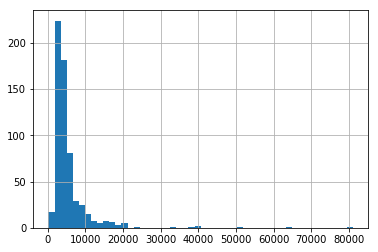

```python
import matplotlib.pyplot as plt

df['ApplicantIncome'].hist(bins=50)
plt.show()
```

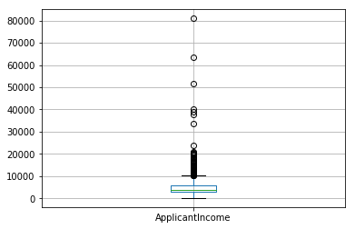

```python
df.boxplot(column='ApplicantIncome')
plt.show()
```

#### This confirms the presence of a lot of outliers/extreme values.

#### Let us categorize income by level of education:

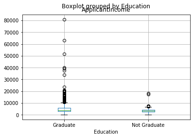

```python
df.boxplot(column='ApplicantIncome', by = 'Education')
plt.show()
```

### Let’s look at the histogram and boxplot of LoanAmount using the following command:

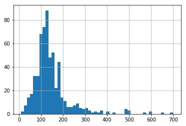

```python
df['LoanAmount'].hist(bins=50)
plt.show()
```

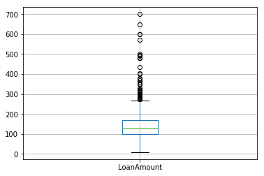

```python
df.boxplot(column='LoanAmount')
plt.show()
```

### Categorical variable analysis

#### Let us look at the chances of getting a loan based on credit history. This can be achieved in MS Excel using a pivot table as:

```python
temp1 = df['Credit_History'].value_counts(ascending=True)
temp2 = df.pivot_table(values='Loan_Status',index=['Credit_History'],aggfunc=lambda x: x.map({'Y':1,'N':0}).mean())
print('Frequency Table for Credit History:')
print(temp1)

print('\nProbility of getting loan for each Credit History class:')
print(temp2)
```

```
Frequency Table for Credit History:
0.0     89
1.0    475
Name: Credit_History, dtype: int64

Probility of getting loan for each Credit History class:
                Loan_Status
Credit_History
0.0                0.078652
1.0                0.795789
```

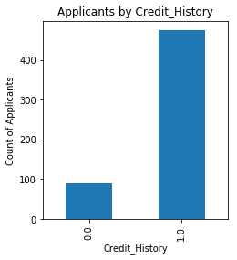

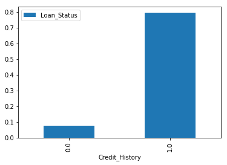

```python
import matplotlib.pyplot as plt
fig = plt.figure(figsize=(8,4))
ax1 = fig.add_subplot(121)
ax1.set_xlabel('Credit_History')
ax1.set_ylabel('Count of Applicants')
ax1.set_title("Applicants by Credit_History")
temp1.plot(kind='bar')
plt.show()

ax2 = fig.add_subplot(122)
temp2.plot(kind = 'bar')
ax2.set_xlabel('Credit_History')
ax2.set_ylabel('Probability of getting loan')
#ax2.set_title("Probability of getting loan by credit history")
plt.show()
```